# Lung Cancer Incidence in Virginia: A spatial zipcode-level analysis via INLA

Indranil Sahoo

2023-07-12

```r
# Required Functions

RelativeSquaredError <- function(realized, predicted, na.rm = TRUE){
  error <- realized - predicted
  mean_realized <- mean(realized, na.rm = na.rm)
  sum(error**2, na.rm = na.rm) / sum((realized - mean_realized)**2, na.rm = na.rm)
}
```

## Overview

In this paper, we focus on analyzing lung cancer counts in Virginia during the years 2014 - 2018, obtained at the zip code level. We explore the use of Poisson and negative binomial spatial regression models to predict lung cancer counts. One salient feature of our data is that covariates relevant to lung cancer such as prevalence of smoking and binge drinking have missing values. Instead of deleting or imputing covaiates using ad hoc techniques, we implement the simultaneous spatial imputation technique proposed in the MIINLA package (https://github.com/becarioprecario/MIINLA), which implements new latent effects with the INLA package for imputation of missing values.

## Data loading and pre-processing

The entire dataset has been coalesced from different sources, and has been made on our GitHub repository. To load the data, please use the following code:

```r
require(sas7bdat)
valung = read.sas7bdat(file = "VAlungcancerzip.sas7bdat", encoding="", debug=FALSE)
```

Among the zip codes in the data, 5 zip codes have no information available and one additional zip code have no spatial information (neighborhood) available. As a result, these zip codes have been deleted from the data, and also removed carefully from the spatial neighborhood matrix.

```r
# Deleting rows with no information (total population = 0)
NANidx <- is.nan(as.matrix(valung))
for(i in 1:dim(NANidx)[2]){
  temp <- valung[[i]]
  temp[is.nan(temp)] <- NA
  valung[[i]] <- temp
}
totpop <- valung$Population_18andOver
index0 <- which(totpop == 0)
zipcode  <- valung$ZCTA5
zipcode0 <- zipcode[index0]

# Creating adjacency matrix of all VA zipcodes

spatial_obj <- tigris::zctas(state = "VA", year = 2010, progress_bar = FALSE)

deleteindex <- double()
for(i in 1:length(index0)){
  deleteindex[i] <- which(spatial_obj$ZCTA5CE10 == zipcode0[i])
}

spatial_obj_dlt <- spatial_obj[-deleteindex, ]
W <- spdep::nb2mat(spdep::poly2nb(spatial_obj_dlt), style = "B", zero.policy = TRUE)
dim(W)
```

```
## [1] 891 891
```

```r
#### Check that our dimensions match, and that is = 891! This is good. Now let's roll

valung <- valung[-index0, ]
#ordering <- sort(as.double(spatial_obj_dlt$ZCTA5CE10), index.return = TRUE)
valung_rearr <- valung[match(as.double(spatial_obj_dlt$ZCTA5CE10),
                             valung$ZCTA5), ]

junk <- rowSums(W)== 0        ### deleting zipcode(s) with no spatial adjacency
W    <- W[!junk, ]
W    <- W[, !junk]
valung_rearr <- valung_rearr[!junk, ]

valung_rearr %>%
  summarise_all(~sum(is.na(.)))
```

```
##   ZCTA5 Zip_name Population_18andOver Pct_Civilian_Unemployed
## 1     0        0                    0                      10
##   Pct_BelowPoverty_18andOver Pct_Population_Male_18andOver
## 1                         11                             0
##   Pct_Population_65andOver Pct_Population_Male_65andOver
## 1                        0                             0
##   Pct_Population_Female_65andOver Pct_Black_18andOver Pct_Black_Male_18andOver
## 1                               0                   0                        0
##   Pct_Black_Female_18andOver Pct_Black_65andOver Pct_Black_Male_65andOver
## 1                          0                   0                        0
##   Pct_Black_Female_65andOver Pct_White_18andOver Pct_White_Male_18andOver
## 1                          0                   0                        0
##   Pct_White_Female_18andOver Pct_White_65andOver Pct_White_Male_65andOver
## 1                          0                   0                        0
##   Pct_White_Female_65andOver Pct_Hisp_18andOver Pct_Hisp_Male_18andOver
## 1                          0                  0                       0
##   Pct_Hisp_Female_18andOver Pct_Hisp_65andOver Pct_Hisp_Male_65andOver
## 1                         0                  0                       0
##   Pct_Hisp_Female_65andOver BINGE_CrudePrev CSMOKING_CrudePrev
## 1                         0               7                  7
##   OBESITY_CrudePrev Median_Household_Income ZCTA_pm2_5 sdi_score case_n_18plus
## 1                 7                      80          0         0            62
```

This shows that, among the 890 zip code data records included in the analysis, 62 (approximately 7%) have missing lung cancer counts. Among the covariates, the percentages of population currently smoking, binge drinking and suffering from obesity have missing values in 7 zip codes (approximately 0.7% missing) and the percentage population below poverty have missing values in 11 zip codes (approximately 1.2% missing). We have not used percentage civilian unemployed and median household income in the study since they are known to be correlated with the Social Deprivation Index (SDI).

## Exploratory analysis of lung cancer counts

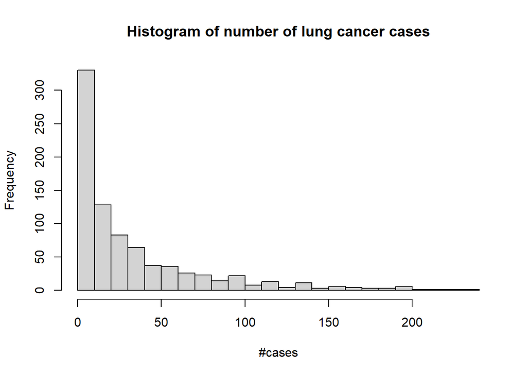

```r
ncases <- valung_rearr$case_n_18plus
hist(ncases, breaks = 20, main = "Histogram of number of lung cancer cases",
     xlab = "#cases")
```

```r
mean(ncases, na.rm = T)
```

```
## [1] 33.22101
```

```r
sd(ncases, na.rm = T)
```

```
## [1] 41.78691
```

```r
indexNA <- which(is.na(ncases))
ncases_noNA <- ncases[-indexNA]
spatial_obj_dltNA <- spatial_obj_dlt[-c(indexNA, junk), ]
Wlist <- spdep::nb2listw(spdep::poly2nb(spatial_obj_dltNA), style = "B", zero.policy = TRUE)
moran.mc(x = ncases_noNA, listw = Wlist, nsim = 1000, zero.policy = TRUE,
         na.action = na.omit)
```

```
##
##  Monte-Carlo simulation of Moran I
##
## data:  ncases_noNA
## weights: Wlist
## number of simulations + 1: 1001
##
## statistic = 0.26312, observed rank = 1001, p-value = 0.000999
## alternative hypothesis: greater
```

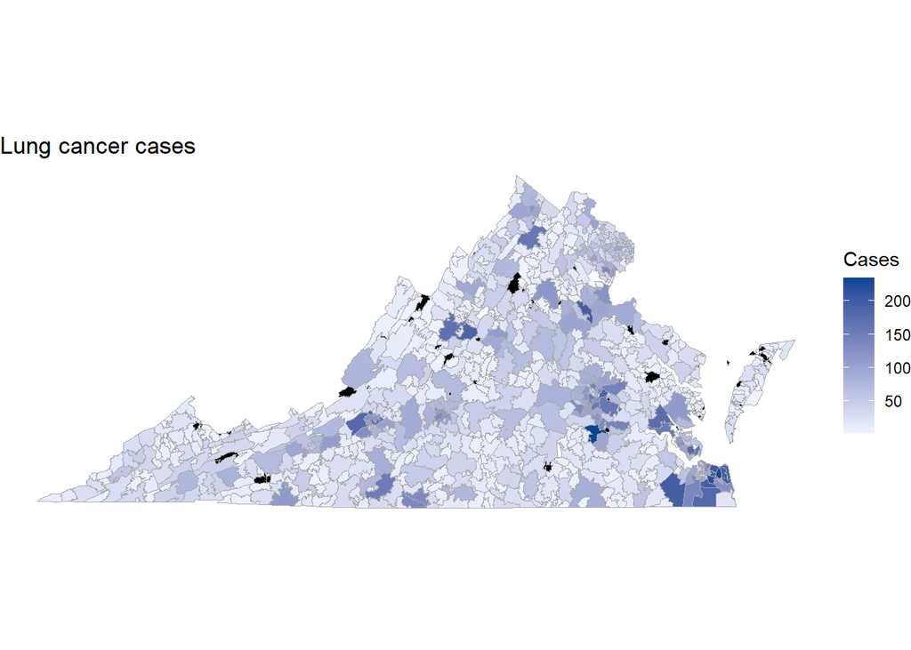

```r
# Spatial map of observed counts

zipcodes  <- valung_rearr$ZCTA5
plotdf_ncases  <- data.frame(as.character(zipcodes), ncases)
colnames(plotdf_ncases) <- c("region", "value")
ec_states = "virginia"
zip_choropleth(plotdf_ncases,
               state_zoom = ec_states,
               num_colors = 1,
               title      = "Lung cancer cases",
               legend     = "Cases") + coord_map()
```

## Spatial imputation of missing covariates using MIINLA

In this part, we set up our covariates and the spatial neighborhood matrix so that they are compatible with the MIINLA package. Covariates must be scaled before they are using in the functions from MIINLA.

```r
# Covariates
# must be scaled to be compatible with MIINLA

zipcodes  <- valung_rearr$ZCTA5
sdi_score <- scale(valung_rearr$sdi_score)[, 1]
pm2.5     <- scale(valung_rearr$ZCTA_pm2_5)[, 1]
totalpop  <- valung_rearr$Population_18andOver     #offset
prcnt_black <- scale(valung_rearr$Pct_Black_18andOver)[, 1]
prcnt_white <- scale(valung_rearr$Pct_White_18andOver)[, 1]
prcnt_hisp  <- scale(valung_rearr$Pct_Hisp_18andOver)[, 1]
prcnt_male  <- scale(valung_rearr$Pct_Population_Male_18andOver)[, 1]
prcnt_65over<- scale(valung_rearr$Pct_Population_65andOver)[, 1]


# covariates with missing values
binge_dr    <- scale(valung_rearr$BINGE_CrudePrev)[, 1]
smoking_idx <- scale(valung_rearr$CSMOKING_CrudePrev)[, 1]
obesity_idx <- scale(valung_rearr$OBESITY_CrudePrev)[, 1]
median_inc  <- scale(valung_rearr$Median_Household_Income)[, 1]
pct_unemp   <- scale(valung_rearr$Pct_Civilian_Unemployed)[, 1]
pct_poverty <- scale(valung_rearr$Pct_BelowPoverty_18andOver)[, 1]


exp_count <- totalpop * sum(ncases, na.rm = TRUE) / sum(totalpop)

df.INLA <- data.frame(cbind(ncases, totalpop, exp_count, zipcodes,
                            sdi_score, pm2.5,
                            prcnt_black, prcnt_white, prcnt_hisp,
                            prcnt_male, prcnt_65over,
                            binge_dr, smoking_idx, obesity_idx, pct_poverty))

W.scaled <- W / max(eigen(W)$values)
max(eigen(W.scaled)$values) # check
```

```
## [1] 1
```

## Implementing GLM in INLA with simultaneous missing covariates imputation

In this section, we implement the Poisson and Negative Binomial Generalized Linear Models (GLMs) in INLA, with simultaneous imputations of the missing covaiates, to model the lung cancer counts. Both spatial and non-spatial versions of the GLM have been implemented in our study. For the spatial model, we implement a Leroux spatial covariance structure at the zip code level.

All model comparisons have been done based on DIC, WAIC, negative loglikelihood, RMSE and RSE. Please refer to the paper for details on the models implemented in this study.

```r
model1 = inla.rgeneric.define(inla.rgeneric.micar.model, debug = TRUE,
                              n = nrow(df.INLA),
                              x = df.INLA$binge_dr,
                              idx.na = which(is.na(df.INLA$binge_dr)),
                              W = W.scaled)

model2 = inla.rgeneric.define(inla.rgeneric.micar.model, debug = TRUE,
                              n = nrow(df.INLA),
                              x = df.INLA$smoking_idx,
                              idx.na = which(is.na(df.INLA$smoking_idx)),
                              W = W.scaled)

model3 = inla.rgeneric.define(inla.rgeneric.micar.model, debug = TRUE,
                              n = nrow(df.INLA),
                              x = df.INLA$obesity_idx,
                              idx.na = which(is.na(df.INLA$obesity_idx)),
                              W = W.scaled)

model4 = inla.rgeneric.define(inla.rgeneric.micar.model, debug = TRUE,
                              n = nrow(df.INLA),
                              x = df.INLA$pct_poverty,
                              idx.na = which(is.na(df.INLA$pct_poverty)),
                              W = W.scaled)


df.INLA$idxNA1 <- rep(NA, nrow(df.INLA))
df.INLA$idxNA2 <- rep(NA, nrow(df.INLA))
df.INLA$idxNA3 <- rep(NA, nrow(df.INLA))
df.INLA$idxNA4 <- rep(NA, nrow(df.INLA))

df.INLA$ID        <- 1:length(ncases)
df.INLA$bingeID   <- 1:length(ncases)
df.INLA$smokingID <- 1:length(ncases)
df.INLA$obesityID <- 1:length(ncases)
df.INLA$povertyID  <- 1:length(ncases)
```

# Spatial models

In this section, we perform multiple imputation using a spatial CAR (MCAR) regression model. Details on the model can be found in the manuscript.

```r
formula = ncases ~ 1 + sdi_score + pm2.5 + prcnt_black +
  prcnt_white + prcnt_hisp + prcnt_male + prcnt_65over + offset(log(totalpop)) +

  f(idxNA1, model = model1) +
  f(bingeID, copy = "idxNA1", fixed = FALSE,
    hyper = list(beta = list(prior = "normal", param = c(0, 0.001)))) +

  f(idxNA2, model = model2) +
  f(smokingID, copy = "idxNA2", fixed = FALSE,
    hyper = list(beta = list(prior = "normal", param = c(0, 0.001)))) +

  f(idxNA3, model = model3) +
  f(obesityID, copy = "idxNA3", fixed = FALSE,
    hyper = list(beta = list(prior = "normal", param = c(0, 0.001)))) +

  f(idxNA4, model = model4) +
  f(povertyID, copy = "idxNA4", fixed = FALSE,
    hyper = list(beta = list(prior = "normal", param = c(0, 0.001)))) +

  f(ID, model = "generic1", Cmatrix = W.scaled)

## Poisson family
IMoutput.pMCAR = inla(formula, data = as.data.frame(df.INLA),
                      family = "poisson", verbose = FALSE,
                      control.predictor = list(compute = TRUE),
                      control.compute = list(dic = TRUE, waic = TRUE,
                                             mlik = TRUE))
IMoutput.pMCAR <- inla.rerun(IMoutput.pMCAR)
summary(IMoutput.pMCAR)
```

```
##
## Call:
##    c("inla.core(formula = formula, family = family, contrasts = contrasts,
##    ", " data = data, quantiles = quantiles, E = E, offset = offset, ", "
##    scale = scale, weights = weights, Ntrials = Ntrials, strata = strata,
##    ", " lp.scale = lp.scale, link.covariates = link.covariates, verbose =
##    verbose, ", " lincomb = lincomb, selection = selection, control.compute
##    = control.compute, ", " control.predictor = control.predictor,
##    control.family = control.family, ", " control.inla = control.inla,
##    control.fixed = control.fixed, ", " control.mode = control.mode,
##    control.expert = control.expert, ", " control.hazard = control.hazard,
##    control.lincomb = control.lincomb, ", " control.update =
##    control.update, control.lp.scale = control.lp.scale, ", "
##    control.pardiso = control.pardiso, only.hyperparam = only.hyperparam,
##    ", " inla.call = inla.call, inla.arg = inla.arg, num.threads =
##    num.threads, ", " blas.num.threads = blas.num.threads, keep = keep,
##    working.directory = working.directory, ", " silent = silent, inla.mode
##    = inla.mode, safe = FALSE, debug = debug, ", " .parent.frame =
##    .parent.frame)")
## Time used:
##     Pre = 1.13, Running = 132, Post = 0.401, Total = 134
## Fixed effects:
##                mean    sd 0.025quant 0.5quant 0.975quant   mode kld
## (Intercept)  -5.243 0.016     -5.274   -5.243     -5.213 -5.243   0
## sdi_score     0.050 0.014      0.021    0.050      0.076  0.051   0
## pm2.5        -0.089 0.015     -0.118   -0.089     -0.059 -0.088   0
## prcnt_black   0.212 0.046      0.122    0.212      0.301  0.212   0
## prcnt_white   0.255 0.046      0.165    0.255      0.345  0.255   0
## prcnt_hisp   -0.039 0.015     -0.068   -0.039     -0.009 -0.039   0
## prcnt_male   -0.096 0.020     -0.137   -0.096     -0.056 -0.096   0
## prcnt_65over  0.211 0.022      0.167    0.211      0.254  0.211   0
##
## Random effects:
##   Name     Model
##     idxNA1 RGeneric2
##    idxNA2 RGeneric2
##    idxNA3 RGeneric2
##    idxNA4 RGeneric2
##    ID Generic1 model
##    bingeID Copy
```

[output cut: 21 more lines]

```
## Beta for smokingID  0.136 0.030      0.075    0.137      0.192  0.140
## Beta for obesityID  0.046 0.030     -0.011    0.045      0.108  0.041
## Beta for povertyID -0.083 0.026     -0.135   -0.084     -0.031 -0.084
##
## Deviance Information Criterion (DIC) ...............: 5007.13
## Deviance Information Criterion (DIC, saturated) ....: -3689.74
## Effective number of parameters .....................: 286.14
##
## Watanabe-Akaike information criterion (WAIC) ...: 5010.27
## Effective number of parameters .................: 229.55
##
## Marginal log-Likelihood:  -7019.54
##  is computed
## Posterior summaries for the linear predictor and the fitted values are computed
## (Posterior marginals needs also 'control.compute=list(return.marginals.predictor=TRUE)')
```

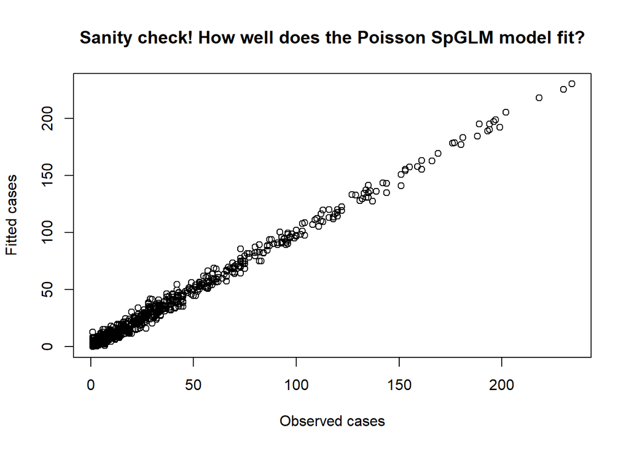

```r
IMoutput.pMCAR.fitted <- IMoutput.pMCAR$summary.fitted.values$mean
IMoutput.pMCAR.fitted <- abs(IMoutput.pMCAR.fitted)
plot(ncases[-which(is.na(ncases))], IMoutput.pMCAR.fitted[-which(is.na(ncases))],
     main = "Sanity check! How well does the Poisson SpGLM model fit?",
     xlab = "Observed cases", ylab = "Fitted cases")
```

```r
#RSE Sp Poisson with imputation
RelativeSquaredError(realized = ncases, predicted = IMoutput.pMCAR.fitted)
```

```
## [1] 0.007218804
```

```r
#RMSE Sp Poisson with imputation
RMSE.p <-
  sqrt(mean((ncases[-which(is.na(ncases))] - IMoutput.pMCAR.fitted[-which(is.na(ncases))])^2))
RMSE.p
```

```
## [1] 3.548219
```

```r
## Negative binomial family
IMoutput.nbMCAR = inla(formula, data = as.data.frame(df.INLA),
                       family = "nbinomial", verbose = FALSE,
                       control.predictor = list(compute = TRUE),
                       control.compute = list(dic = TRUE, waic = TRUE,
                                              mlik = TRUE))
IMoutput.nbMCAR <- inla.rerun(IMoutput.nbMCAR)
summary(IMoutput.nbMCAR)
```

```
##
## Call:
##    c("inla.core(formula = formula, family = family, contrasts = contrasts,
##    ", " data = data, quantiles = quantiles, E = E, offset = offset, ", "
##    scale = scale, weights = weights, Ntrials = Ntrials, strata = strata,
##    ", " lp.scale = lp.scale, link.covariates = link.covariates, verbose =
##    verbose, ", " lincomb = lincomb, selection = selection, control.compute
##    = control.compute, ", " control.predictor = control.predictor,
##    control.family = control.family, ", " control.inla = control.inla,
##    control.fixed = control.fixed, ", " control.mode = control.mode,
##    control.expert = control.expert, ", " control.hazard = control.hazard,
##    control.lincomb = control.lincomb, ", " control.update =
##    control.update, control.lp.scale = control.lp.scale, ", "
##    control.pardiso = control.pardiso, only.hyperparam = only.hyperparam,
##    ", " inla.call = inla.call, inla.arg = inla.arg, num.threads =
##    num.threads, ", " blas.num.threads = blas.num.threads, keep = keep,
##    working.directory = working.directory, ", " silent = silent, inla.mode
##    = inla.mode, safe = FALSE, debug = debug, ", " .parent.frame =
##    .parent.frame)")
## Time used:
##     Pre = 1.1, Running = 151, Post = 0.416, Total = 153
## Fixed effects:
##                mean    sd 0.025quant 0.5quant 0.975quant   mode kld
## (Intercept)  -5.240 0.015     -5.270   -5.240     -5.210 -5.239   0
## sdi_score     0.040 0.014      0.013    0.039      0.067  0.039   0
## pm2.5        -0.086 0.015     -0.115   -0.086     -0.057 -0.086   0
## prcnt_black   0.209 0.047      0.117    0.209      0.300  0.209   0
## prcnt_white   0.250 0.047      0.158    0.250      0.341  0.250   0
## prcnt_hisp   -0.040 0.015     -0.070   -0.040     -0.010 -0.040   0
## prcnt_male   -0.099 0.021     -0.140   -0.099     -0.059 -0.099   0
## prcnt_65over  0.212 0.023      0.168    0.213      0.256  0.213   0
##
## Random effects:
##   Name     Model
##     idxNA1 RGeneric2
##    idxNA2 RGeneric2
##    idxNA3 RGeneric2
##    idxNA4 RGeneric2
##    ID Generic1 model
##    bingeID Copy
```

[output cut: 62 more lines]

```
## Beta for smokingID                                          0.196   0.139
## Beta for obesityID                                          0.112   0.048
## Beta for povertyID                                         -0.024  -0.071
##
## Deviance Information Criterion (DIC) ...............: 5062.60
## Deviance Information Criterion (DIC, saturated) ....: -3634.26
## Effective number of parameters .....................: 260.63
##
## Watanabe-Akaike information criterion (WAIC) ...: 5057.44
## Effective number of parameters .................: 205.55
##
## Marginal log-Likelihood:  -7019.06
##  is computed
## Posterior summaries for the linear predictor and the fitted values are computed
## (Posterior marginals needs also 'control.compute=list(return.marginals.predictor=TRUE)')
```

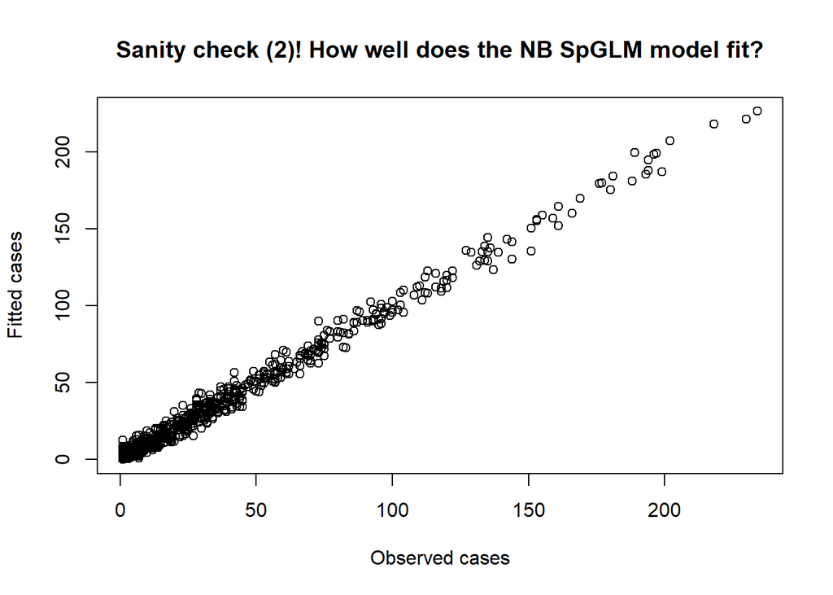

```r
IMoutput.nbMCAR.fitted <- IMoutput.nbMCAR$summary.fitted.values$mean
IMoutput.nbMCAR.fitted <- abs(IMoutput.nbMCAR.fitted)
plot(ncases[-which(is.na(ncases))], IMoutput.nbMCAR.fitted[-which(is.na(ncases))],
     main = "Sanity check (2)! How well does the NB SpGLM model fit?",
     xlab = "Observed cases", ylab = "Fitted cases")
```

```r
#RSE Sp Neg Bin with imputation
RelativeSquaredError(realized = ncases, predicted = IMoutput.nbMCAR.fitted)
```

```
## [1] 0.009455238
```

```r
#RMSE Sp Neg Bin with imputation
RMSE.nb <-
  sqrt(mean((ncases[-which(is.na(ncases))] - IMoutput.nbMCAR.fitted[-which(is.na(ncases))])^2))
RMSE.nb
```

```
## [1] 4.060823
```

# Non-spatial models

We implement simultaneous covariate imputations by introducing latent effects which are linear on some covariates with missing observations. However, multiple imputation is performed on the missing values of the covariates internally using a linear regression model. No spatial covariance is included in these models.

```r
obs.cov <- cbind(1, sdi_score, pm2.5, prcnt_black, prcnt_white, prcnt_hisp,
                 prcnt_male, prcnt_65over)

model1.nsp = inla.rgeneric.define(inla.rgeneric.milm.model, debug = TRUE,
                                  x = df.INLA$binge_dr,
                                  XX = obs.cov,
                                  n = nrow(df.INLA),
                                  idx.na = which(is.na(df.INLA$binge_dr)))

model2.nsp = inla.rgeneric.define(inla.rgeneric.milm.model, debug = TRUE,
                                  x = df.INLA$smoking_idx,
                                  XX = obs.cov,
                                  n = nrow(df.INLA),
                                  idx.na = which(is.na(df.INLA$smoking_idx)))


model3.nsp = inla.rgeneric.define(inla.rgeneric.milm.model, debug = TRUE,
                                  x = df.INLA$obesity_idx,
                                  XX = obs.cov,
                                  n = nrow(df.INLA),
                                  idx.na = which(is.na(df.INLA$obesity_idx)))


model4.nsp = inla.rgeneric.define(inla.rgeneric.milm.model, debug = TRUE,
                                  x = df.INLA$pct_poverty,
                                  XX = obs.cov,
                                  n = nrow(df.INLA),
                                  idx.na = which(is.na(df.INLA$pct_poverty)))



formula.nsp = ncases ~ 1 + sdi_score + pm2.5 + prcnt_black       +prcnt_white + prcnt_hisp + prcnt_male + prcnt_65over + offset(log(totalpop)) +

  f(idxNA1, model = model1.nsp) +
  f(bingeID, copy = "idxNA1", fixed = FALSE,
    hyper = list(beta = list(prior = "normal", param = c(0, 0.001)))) +

  f(idxNA2, model = model2.nsp) +
  f(smokingID, copy = "idxNA2", fixed = FALSE,
    hyper = list(beta = list(prior = "normal", param = c(0, 0.001)))) +

  f(idxNA3, model = model3.nsp) +
  f(obesityID, copy = "idxNA3", fixed = FALSE,
    hyper = list(beta = list(prior = "normal", param = c(0, 0.001)))) +

  f(idxNA4, model = model4.nsp) +
  f(povertyID, copy = "idxNA4", fixed = FALSE,
    hyper = list(beta = list(prior = "normal", param = c(0, 0.001))))


## Poisson family

IMoutput.pMCAR.nsp = inla(formula.nsp, data = as.data.frame(df.INLA),
                          family = "poisson", verbose = FALSE,
                          control.predictor = list(compute = TRUE),
                          control.compute = list(dic = TRUE, waic = TRUE,
                                                 mlik = TRUE))
IMoutput.pMCAR.nsp <- inla.rerun(IMoutput.pMCAR.nsp)
summary(IMoutput.pMCAR.nsp)
```

```
##
## Call:
##    c("inla.core(formula = formula, family = family, contrasts = contrasts,
##    ", " data = data, quantiles = quantiles, E = E, offset = offset, ", "
##    scale = scale, weights = weights, Ntrials = Ntrials, strata = strata,
##    ", " lp.scale = lp.scale, link.covariates = link.covariates, verbose =
##    verbose, ", " lincomb = lincomb, selection = selection, control.compute
##    = control.compute, ", " control.predictor = control.predictor,
##    control.family = control.family, ", " control.inla = control.inla,
##    control.fixed = control.fixed, ", " control.mode = control.mode,
##    control.expert = control.expert, ", " control.hazard = control.hazard,
##    control.lincomb = control.lincomb, ", " control.update =
##    control.update, control.lp.scale = control.lp.scale, ", "
##    control.pardiso = control.pardiso, only.hyperparam = only.hyperparam,
##    ", " inla.call = inla.call, inla.arg = inla.arg, num.threads =
##    num.threads, ", " blas.num.threads = blas.num.threads, keep = keep,
##    working.directory = working.directory, ", " silent = silent, inla.mode
##    = inla.mode, safe = FALSE, debug = debug, ", " .parent.frame =
##    .parent.frame)")
## Time used:
##     Pre = 0.966, Running = 175, Post = 1.42, Total = 178
## Fixed effects:
##                mean    sd 0.025quant 0.5quant 0.975quant   mode kld
## (Intercept)  -5.224 0.008     -5.240   -5.224     -5.209 -5.224   0
## sdi_score     0.066 0.014      0.040    0.065      0.093  0.063   0
## pm2.5        -0.066 0.007     -0.081   -0.066     -0.052 -0.066   0
## prcnt_black   0.246 0.033      0.179    0.246      0.311  0.246   0
## prcnt_white   0.273 0.032      0.210    0.273      0.335  0.273   0
## prcnt_hisp   -0.048 0.009     -0.066   -0.048     -0.030 -0.048   0
## prcnt_male   -0.081 0.017     -0.114   -0.081     -0.049 -0.081   0
## prcnt_65over  0.273 0.020      0.234    0.273      0.312  0.272   0
##
## Random effects:
##   Name     Model
##     idxNA1 RGeneric2
##    idxNA2 RGeneric2
##    idxNA3 RGeneric2
##    idxNA4 RGeneric2
##    bingeID Copy
##    smokingID Copy
```

[output cut: 42 more lines]

```
## Beta for smokingID  0.156 0.017      0.122    0.156      0.190  0.157
## Beta for obesityID  0.050 0.017      0.016    0.050      0.084  0.050
## Beta for povertyID -0.142 0.018     -0.177   -0.142     -0.107 -0.141
##
## Deviance Information Criterion (DIC) ...............: 5446.90
## Deviance Information Criterion (DIC, saturated) ....: -3249.97
## Effective number of parameters .....................: 12.44
##
## Watanabe-Akaike information criterion (WAIC) ...: 5465.77
## Effective number of parameters .................: 30.11
##
## Marginal log-Likelihood:  -3713.45
##  is computed
## Posterior summaries for the linear predictor and the fitted values are computed
## (Posterior marginals needs also 'control.compute=list(return.marginals.predictor=TRUE)')
```

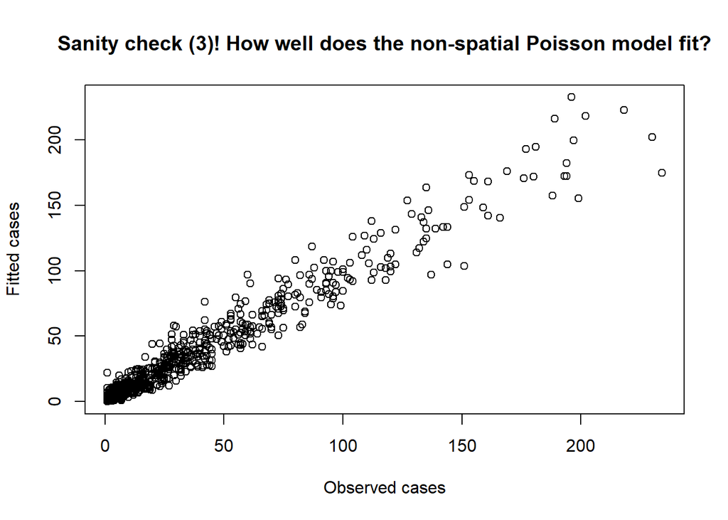

```r
IMoutput.pMCAR.fitted.nsp <- IMoutput.pMCAR.nsp$summary.fitted.values$mean
IMoutput.pMCAR.fitted.nsp <- abs(IMoutput.pMCAR.fitted.nsp)
plot(ncases[-which(is.na(ncases))], IMoutput.pMCAR.fitted.nsp[-which(is.na(ncases))],
     main = "Sanity check (3)! How well does the non-spatial Poisson model fit?",
     xlab = "Observed cases", ylab = "Fitted cases")
```

```r
#RSE non spatial Poisson with imputation
RelativeSquaredError(realized = ncases, predicted = IMoutput.pMCAR.fitted.nsp)
```

```
## [1] 0.04583799
```

```r
#RMSE non Sp Poisson with imputation
RMSE.p.nsp <-
  sqrt(mean((ncases[-which(is.na(ncases))] - IMoutput.pMCAR.fitted.nsp[-which(is.na(ncases))])^2))
RMSE.p.nsp
```

```
## [1] 8.941094
```

```r
## Negative Binomial family

IMoutput.nbMCAR.nsp = inla(formula.nsp, data = as.data.frame(df.INLA),
                           family = "nbinomial", verbose = FALSE,
                           control.predictor = list(compute = TRUE),
                           control.compute = list(dic = TRUE, waic = TRUE,
                                                  mlik = TRUE))
IMoutput.nbMCAR.nsp <- inla.rerun(IMoutput.nbMCAR.nsp)
summary(IMoutput.nbMCAR.nsp)
```

```
##
## Call:
##    c("inla.core(formula = formula, family = family, contrasts = contrasts,
##    ", " data = data, quantiles = quantiles, E = E, offset = offset, ", "
##    scale = scale, weights = weights, Ntrials = Ntrials, strata = strata,
##    ", " lp.scale = lp.scale, link.covariates = link.covariates, verbose =
##    verbose, ", " lincomb = lincomb, selection = selection, control.compute
##    = control.compute, ", " control.predictor = control.predictor,
##    control.family = control.family, ", " control.inla = control.inla,
##    control.fixed = control.fixed, ", " control.mode = control.mode,
##    control.expert = control.expert, ", " control.hazard = control.hazard,
##    control.lincomb = control.lincomb, ", " control.update =
##    control.update, control.lp.scale = control.lp.scale, ", "
##    control.pardiso = control.pardiso, only.hyperparam = only.hyperparam,
##    ", " inla.call = inla.call, inla.arg = inla.arg, num.threads =
##    num.threads, ", " blas.num.threads = blas.num.threads, keep = keep,
##    working.directory = working.directory, ", " silent = silent, inla.mode
##    = inla.mode, safe = FALSE, debug = debug, ", " .parent.frame =
##    .parent.frame)")
## Time used:
##     Pre = 1.05, Running = 170, Post = 1.31, Total = 173
## Fixed effects:
##                mean    sd 0.025quant 0.5quant 0.975quant   mode kld
## (Intercept)  -5.219 0.011     -5.241   -5.219     -5.196 -5.219   0
## sdi_score     0.032 0.016      0.000    0.032      0.062  0.032   0
## pm2.5        -0.075 0.012     -0.099   -0.075     -0.051 -0.075   0
## prcnt_black   0.255 0.045      0.165    0.255      0.344  0.255   0
## prcnt_white   0.268 0.045      0.180    0.268      0.357  0.268   0
## prcnt_hisp   -0.053 0.015     -0.083   -0.053     -0.023 -0.053   0
## prcnt_male   -0.101 0.021     -0.143   -0.101     -0.059 -0.101   0
## prcnt_65over  0.228 0.023      0.181    0.228      0.273  0.228   0
##
## Random effects:
##   Name     Model
##     idxNA1 RGeneric2
##    idxNA2 RGeneric2
##    idxNA3 RGeneric2
##    idxNA4 RGeneric2
##    bingeID Copy
##    smokingID Copy
```

[output cut: 127 more lines]

```
## Beta for smokingID                                      0.137
## Beta for obesityID                                      0.047
## Beta for povertyID                                     -0.072
##
## Deviance Information Criterion (DIC) ...............: 5205.08
## Deviance Information Criterion (DIC, saturated) ....: -3491.79
## Effective number of parameters .....................: 11.38
##
## Watanabe-Akaike information criterion (WAIC) ...: 5207.39
## Effective number of parameters .................: 13.38
##
## Marginal log-Likelihood:  -3589.71
##  is computed
## Posterior summaries for the linear predictor and the fitted values are computed
## (Posterior marginals needs also 'control.compute=list(return.marginals.predictor=TRUE)')
```

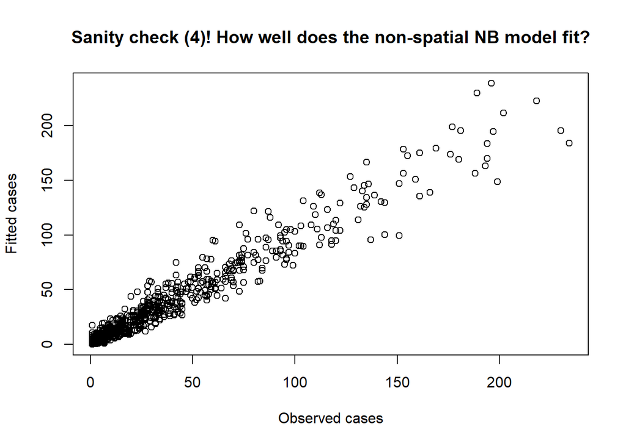

```r
IMoutput.nbMCAR.fitted.nsp <- IMoutput.nbMCAR.nsp$summary.fitted.values$mean
IMoutput.nbMCAR.fitted.nsp <- abs(IMoutput.nbMCAR.fitted.nsp)
plot(ncases[-which(is.na(ncases))], IMoutput.nbMCAR.fitted.nsp[-which(is.na(ncases))],
     main = "Sanity check (4)! How well does the non-spatial NB model fit?",
     xlab = "Observed cases", ylab = "Fitted cases")
```

```r
#RSE non Sp Neg Bin with imputation
RelativeSquaredError(realized = ncases, predicted = IMoutput.nbMCAR.fitted.nsp)
```

```
## [1] 0.05238591
```

```r
#RMSE non Sp Neg Bin with imputation
RMSE.nb.nsp <-
  sqrt(mean((ncases[-which(is.na(ncases))] - IMoutput.nbMCAR.fitted.nsp[-which(is.na(ncases))])^2))
RMSE.nb.nsp
```

```
## [1] 9.558398
```

## Plots from the manuscript

All plots provided in the manuscript can be found below.

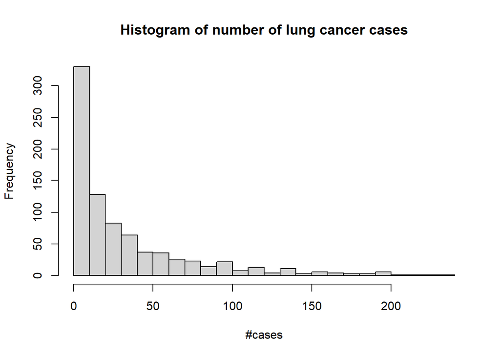

```r
# Response
hist(ncases, breaks = 20, main = "Histogram of number of lung cancer cases",
     xlab = "#cases")
```

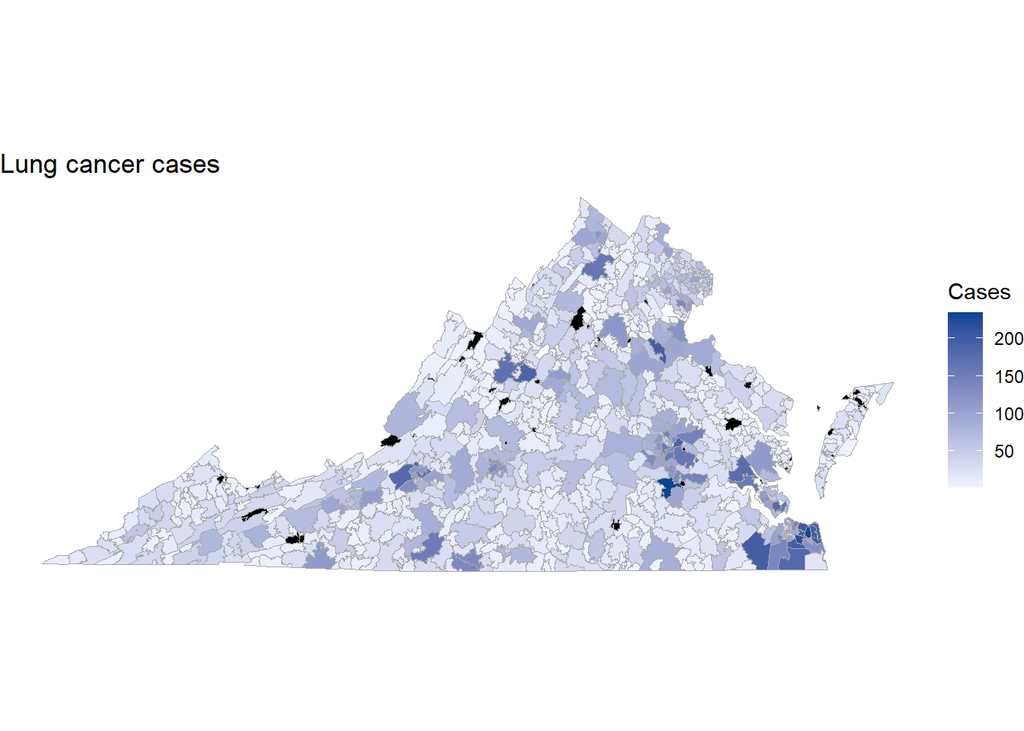

```r
zipcodes  <- valung_rearr$ZCTA5
plotdf_ncases  <- data.frame(as.character(zipcodes), ncases)
colnames(plotdf_ncases) <- c("region", "value")
ec_states = "virginia"
zip_choropleth(plotdf_ncases,
               state_zoom = ec_states,
               num_colors = 1,
               title      = "Lung cancer cases",
               legend     = "Cases") + coord_map()
```

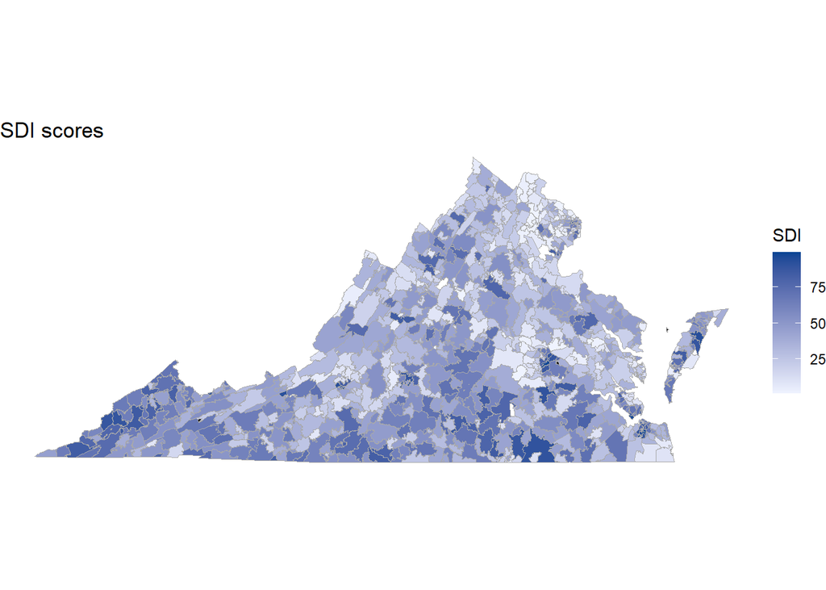

```r
# Predictor variables

plotdf_sdi  <- data.frame(as.character(zipcodes), valung_rearr$sdi_score)
colnames(plotdf_sdi) <- c("region", "value")
zip_choropleth(plotdf_sdi,
               state_zoom = ec_states,
               num_colors = 1,
               title      = "SDI scores",
               legend     = "SDI") + coord_map()
```

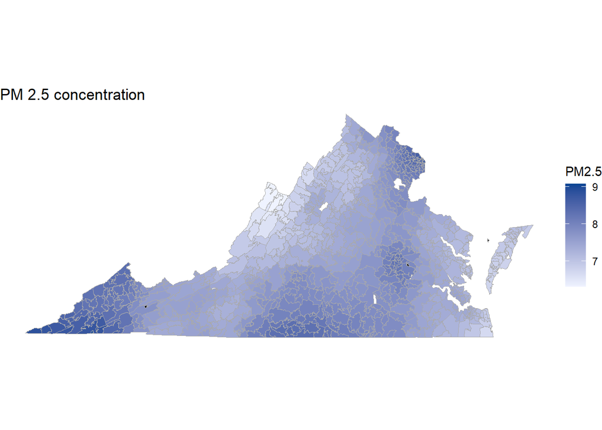

```r
plotdf_pm2.5  <- data.frame(as.character(zipcodes), valung_rearr$ZCTA_pm2_5)
colnames(plotdf_pm2.5) <- c("region", "value")
zip_choropleth(plotdf_pm2.5,
               state_zoom = ec_states,
               num_colors = 1,
               title      = "PM 2.5 concentration",
               legend     = "PM2.5") + coord_map()
```

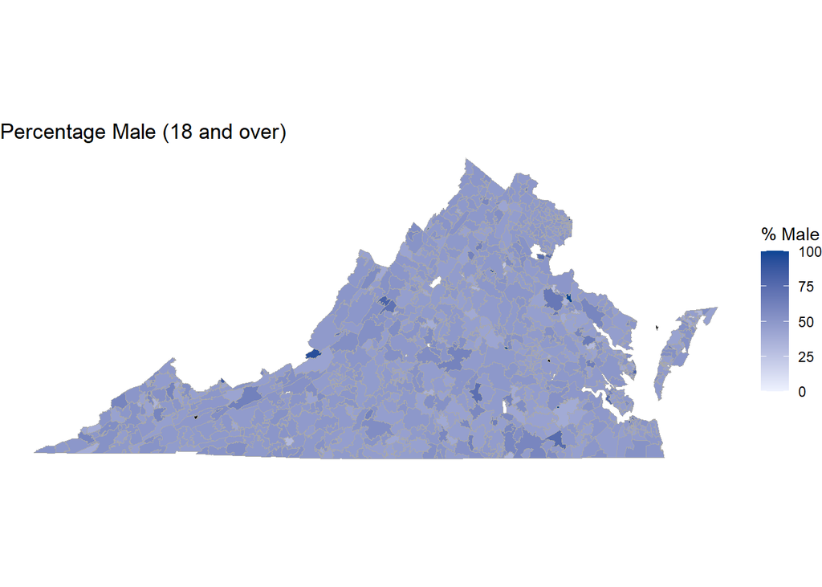

```r
plotdf_male  <- data.frame(as.character(zipcodes),
                           valung_rearr$Pct_Population_Male_18andOver)
colnames(plotdf_male) <- c("region", "value")
zip_choropleth(plotdf_male,
               state_zoom = ec_states,
               num_colors = 1,
               title      = "Percentage Male (18 and over)",
               legend     = "% Male") + coord_map()
```

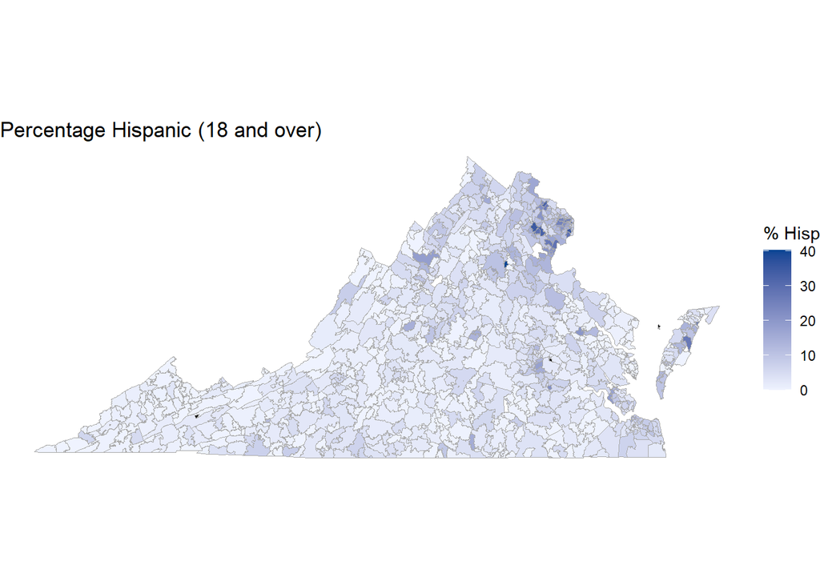

```r
plotdf_hisp  <- data.frame(as.character(zipcodes),
                           valung_rearr$Pct_Hisp_18andOver)
colnames(plotdf_hisp) <- c("region", "value")
zip_choropleth(plotdf_hisp,
               state_zoom = ec_states,
               num_colors = 1,
               title      = "Percentage Hispanic (18 and over)",
               legend     = "% Hisp") + coord_map()
```

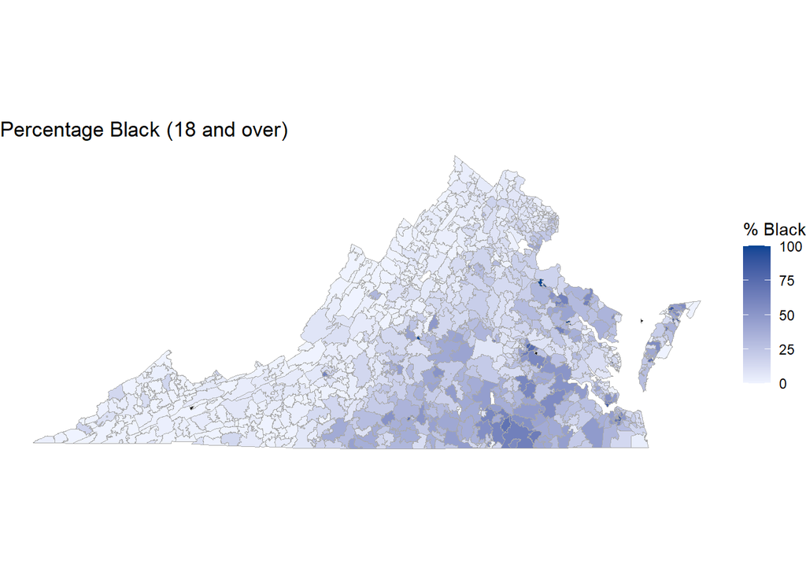

```r
plotdf_blck  <- data.frame(as.character(zipcodes),
                           valung_rearr$Pct_Black_18andOver)
colnames(plotdf_blck) <- c("region", "value")
zip_choropleth(plotdf_blck,
               state_zoom = ec_states,
               num_colors = 1,
               title      = "Percentage Black (18 and over)",
               legend     = "% Black") + coord_map()
```

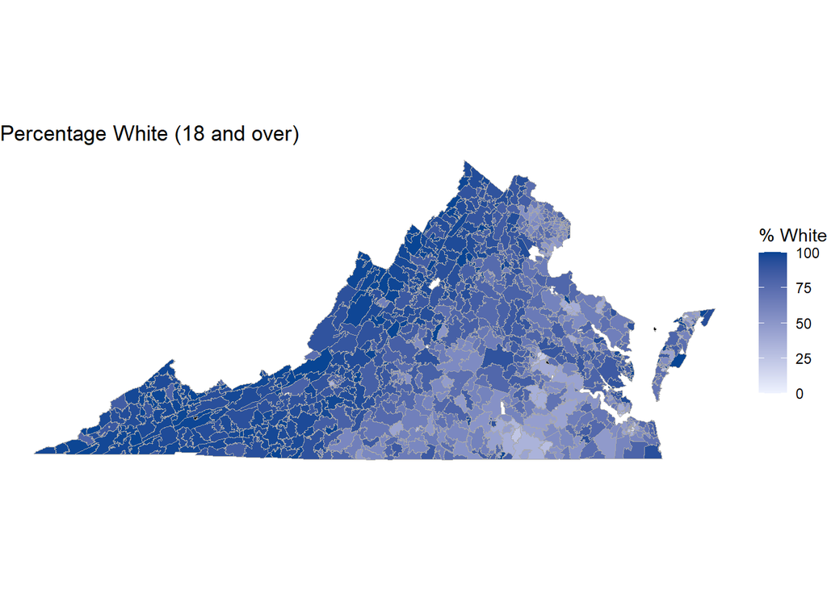

```r
plotdf_wht  <- data.frame(as.character(zipcodes),
                           valung_rearr$Pct_White_18andOver)
colnames(plotdf_wht) <- c("region", "value")
zip_choropleth(plotdf_wht,
               state_zoom = ec_states,
               num_colors = 1,
               title      = "Percentage White (18 and over)",
               legend     = "% White") + coord_map()
```

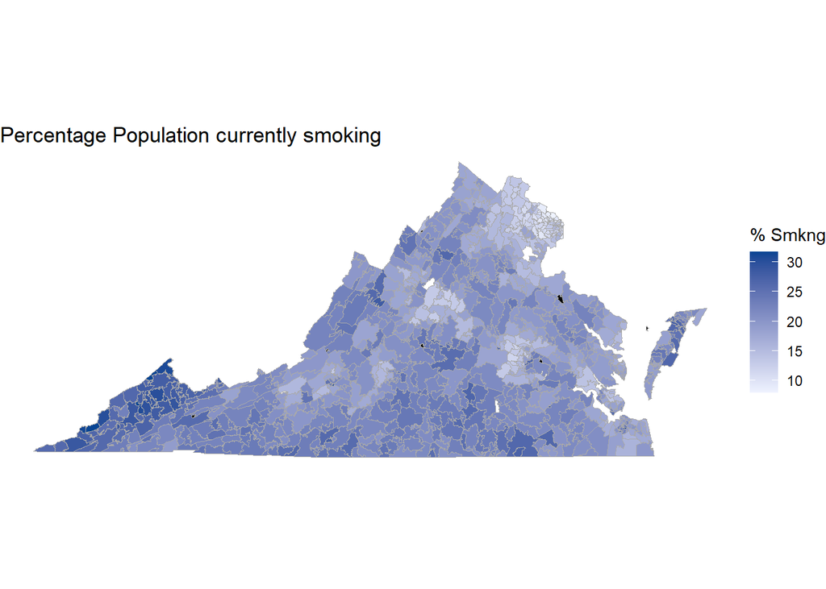

```r
plotdf_smk  <- data.frame(as.character(zipcodes),
                          valung_rearr$CSMOKING_CrudePrev)
colnames(plotdf_smk) <- c("region", "value")
zip_choropleth(plotdf_smk,
               state_zoom = ec_states,
               num_colors = 1,
               title      = "Percentage Population currently smoking",
               legend     = "% Smkng") + coord_map()
```

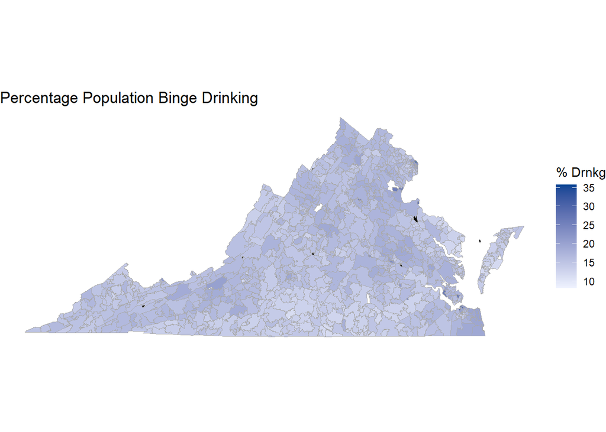

```r
plotdf_drnk  <- data.frame(as.character(zipcodes),
                          valung_rearr$BINGE_CrudePrev)
colnames(plotdf_drnk) <- c("region", "value")
zip_choropleth(plotdf_drnk,
               state_zoom = ec_states,
               num_colors = 1,
               title      = "Percentage Population Binge Drinking",
               legend     = "% Drnkg") + coord_map()
```

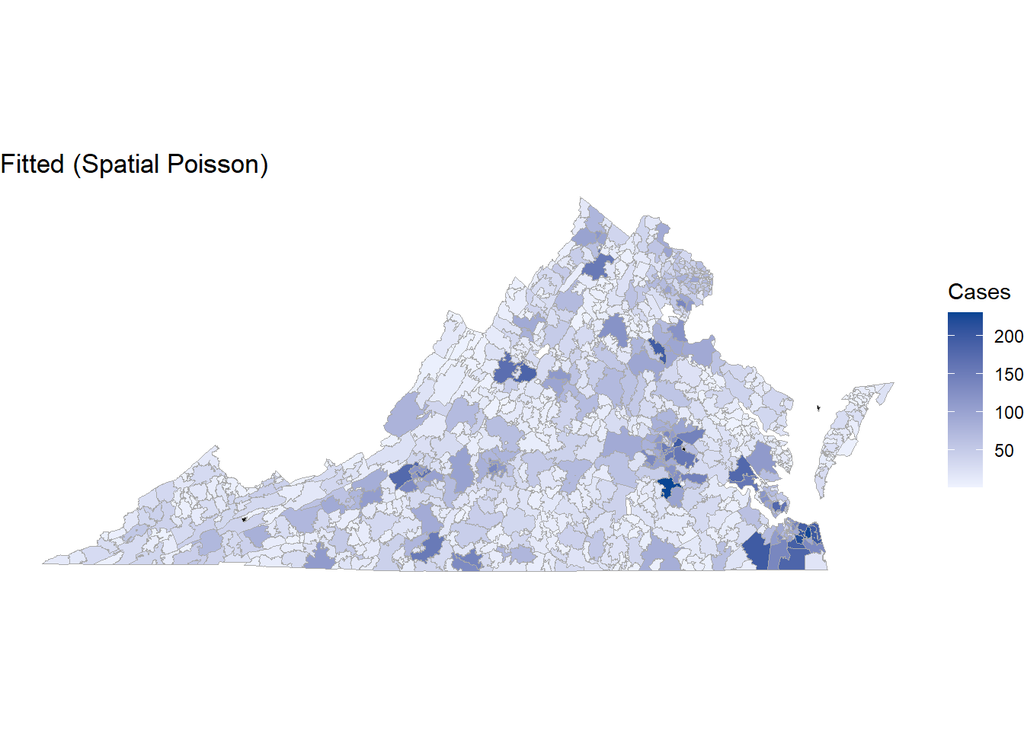

```r
# Fitted value maps for Imputation models

plotdf_fittedSpPoi  <- data.frame(as.character(zipcodes), IMoutput.pMCAR.fitted)
colnames(plotdf_fittedSpPoi) <- c("region", "value")
ec_states = "virginia"
zip_choropleth(plotdf_fittedSpPoi,
               state_zoom = ec_states,
               num_colors = 1,
               title      = "Fitted (Spatial Poisson)",
               legend     = "Cases") + coord_map()
```

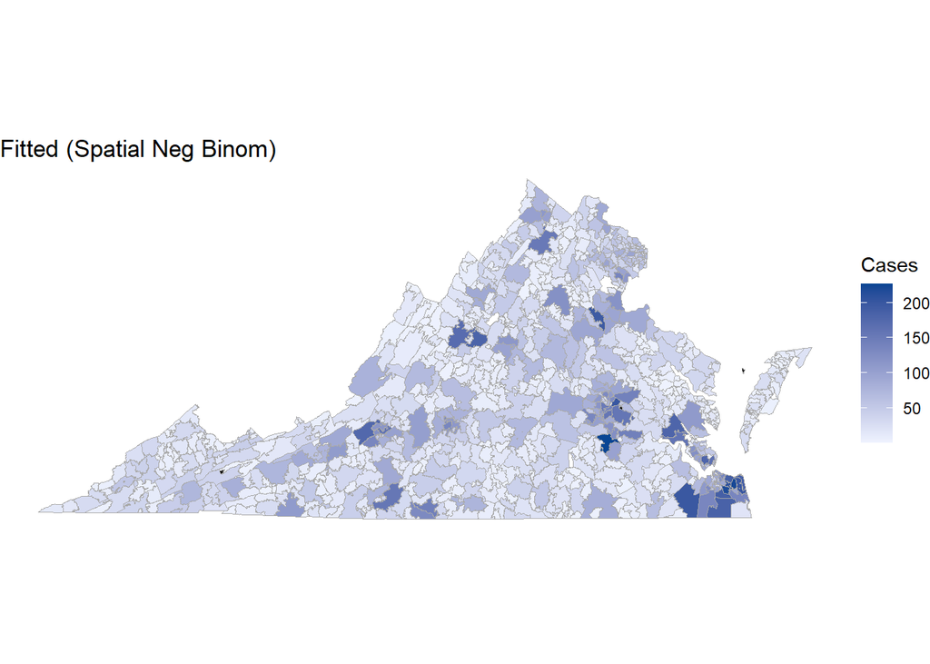

```r
plotdf_fittedSpNB  <- data.frame(as.character(zipcodes), IMoutput.nbMCAR.fitted)
colnames(plotdf_fittedSpNB) <- c("region", "value")
ec_states = "virginia"
zip_choropleth(plotdf_fittedSpNB,
               state_zoom = ec_states,
               num_colors = 1,
               title      = "Fitted (Spatial Neg Binom)",
               legend     = "Cases") + coord_map()
```

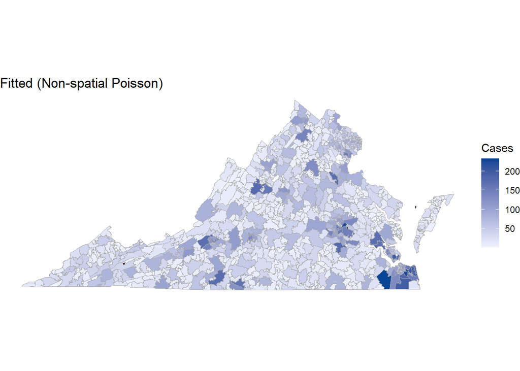

```r
plotdf_fittedNSpPoi  <- data.frame(as.character(zipcodes),
                                   IMoutput.pMCAR.fitted.nsp)
colnames(plotdf_fittedNSpPoi) <- c("region", "value")
ec_states = "virginia"
zip_choropleth(plotdf_fittedNSpPoi,
               state_zoom = ec_states,
               num_colors = 1,
               title      = "Fitted (Non-spatial Poisson)",
               legend     = "Cases") + coord_map()
```

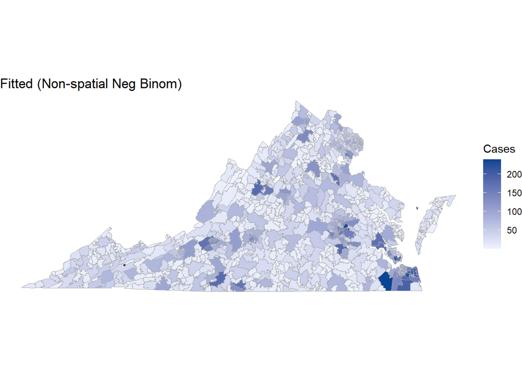

```r
plotdf_fittedNSpNB  <- data.frame(as.character(zipcodes),
                                   IMoutput.nbMCAR.fitted.nsp)
colnames(plotdf_fittedNSpNB) <- c("region", "value")
ec_states = "virginia"
zip_choropleth(plotdf_fittedNSpNB,
               state_zoom = ec_states,
               num_colors = 1,
               title      = "Fitted (Non-spatial Neg Binom)",
               legend     = "Cases") + coord_map()
```

## Comparison with no-imputation models

In this section, we fit spatial and non-spatial Poisson and Negative Binomial GLMs without imputing the missing covariates first. It is to be noted that, within the INLA framework, missing covariates are replaced by 0 (zero). This is mentioned in the FAQ section of the R-INLA package website.

# Spatial models

```r
formula.noimp = ncases ~ 1 + sdi_score + pm2.5 + prcnt_black +
  prcnt_white + prcnt_hisp + prcnt_male + prcnt_65over + binge_dr +
  smoking_idx + obesity_idx + pct_poverty + offset(log(totalpop)) +
  f(ID, model = "generic1", Cmatrix = W.scaled)


# Poisson family
NOIMPoutput.p = inla(formula.noimp, data = as.data.frame(df.INLA),
                     family = "poisson", verbose = FALSE,
                     control.predictor = list(compute = TRUE),
                     control.compute = list(dic = TRUE, waic = TRUE,
                                            mlik = TRUE))
NOIMPoutput.p <- inla.rerun(NOIMPoutput.p)
summary(NOIMPoutput.p)
```

```
##
## Call:
##    c("inla.core(formula = formula, family = family, contrasts = contrasts,
##    ", " data = data, quantiles = quantiles, E = E, offset = offset, ", "
##    scale = scale, weights = weights, Ntrials = Ntrials, strata = strata,
##    ", " lp.scale = lp.scale, link.covariates = link.covariates, verbose =
##    verbose, ", " lincomb = lincomb, selection = selection, control.compute
##    = control.compute, ", " control.predictor = control.predictor,
##    control.family = control.family, ", " control.inla = control.inla,
##    control.fixed = control.fixed, ", " control.mode = control.mode,
##    control.expert = control.expert, ", " control.hazard = control.hazard,
##    control.lincomb = control.lincomb, ", " control.update =
##    control.update, control.lp.scale = control.lp.scale, ", "
##    control.pardiso = control.pardiso, only.hyperparam = only.hyperparam,
##    ", " inla.call = inla.call, inla.arg = inla.arg, num.threads =
##    num.threads, ", " blas.num.threads = blas.num.threads, keep = keep,
##    working.directory = working.directory, ", " silent = silent, inla.mode
##    = inla.mode, safe = FALSE, debug = debug, ", " .parent.frame =
##    .parent.frame)")
## Time used:
##     Pre = 0.692, Running = 2.8, Post = 0.107, Total = 3.6
## Fixed effects:
##                mean    sd 0.025quant 0.5quant 0.975quant   mode kld
## (Intercept)  -5.245 0.017     -5.279   -5.245     -5.212 -5.245   0
## sdi_score     0.049 0.021      0.007    0.049      0.091  0.049   0
## pm2.5        -0.089 0.016     -0.121   -0.089     -0.057 -0.089   0
## prcnt_black   0.195 0.054      0.089    0.195      0.301  0.195   0
## prcnt_white   0.245 0.052      0.143    0.245      0.347  0.245   0
## prcnt_hisp   -0.038 0.016     -0.069   -0.038     -0.007 -0.038   0
## prcnt_male   -0.097 0.022     -0.140   -0.097     -0.054 -0.097   0
## prcnt_65over  0.210 0.028      0.156    0.210      0.264  0.210   0
## binge_dr     -0.104 0.022     -0.148   -0.104     -0.062 -0.104   0
## smoking_idx   0.138 0.029      0.080    0.138      0.195  0.138   0
## obesity_idx   0.048 0.030     -0.011    0.048      0.107  0.048   0
## pct_poverty  -0.081 0.026     -0.133   -0.081     -0.030 -0.081   0
##
## Random effects:
##   Name     Model
##     ID Generic1 model
##
## Model hyperparameters:
##                    mean    sd 0.025quant 0.5quant 0.975quant   mode
## Precision for ID 44.327 6.046     33.721   43.877     57.499 42.934
## Beta for ID       0.979 0.022      0.919    0.986      0.999  0.996
##
## Deviance Information Criterion (DIC) ...............: 5011.08
## Deviance Information Criterion (DIC, saturated) ....: -3685.79
## Effective number of parameters .....................: 286.95
##
## Watanabe-Akaike information criterion (WAIC) ...: 5012.52
## Effective number of parameters .................: 229.28
##
## Marginal log-Likelihood:  -2664.01
##  is computed
## Posterior summaries for the linear predictor and the fitted values are computed
## (Posterior marginals needs also 'control.compute=list(return.marginals.predictor=TRUE)')
```

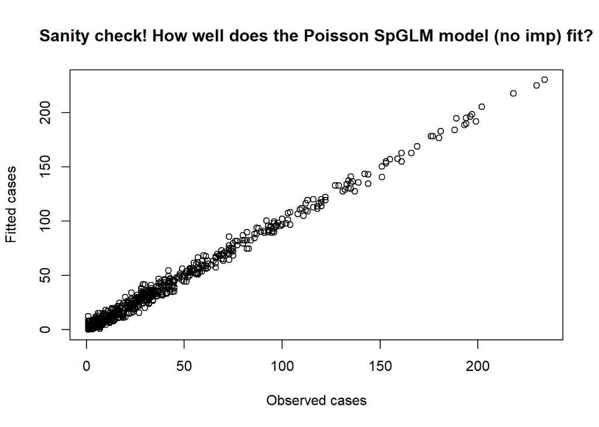

```r
NOIMPoutput.p.fitted <- NOIMPoutput.p$summary.fitted.values$mean
NOIMPoutput.p.fitted <- abs(NOIMPoutput.p.fitted)
plot(ncases[-which(is.na(ncases))], NOIMPoutput.p.fitted[-which(is.na(ncases))],
     main = "Sanity check! How well does the Poisson SpGLM model (no imp) fit?",
     xlab = "Observed cases", ylab = "Fitted cases")
```

```r
#RSE Sp Poisson WITHOUT any imputation
RelativeSquaredError(realized = ncases, predicted = NOIMPoutput.p.fitted)
```

```
## [1] 0.00726263
```

```r
#RMSE Sp Poisson WITHOUT any imputation
RMSE.p.noimp <-
  sqrt(mean((ncases[-which(is.na(ncases))] - NOIMPoutput.p.fitted[-which(is.na(ncases))])^2))
RMSE.p.noimp
```

```
## [1] 3.558974
```

```r
# NB family
NOIMPoutput.nb = inla(formula.noimp, data = as.data.frame(df.INLA),
                      family = "nbinomial", verbose = FALSE,
                      control.family = list(link = 'log'),
                      control.predictor = list(compute = TRUE),
                      control.compute = list(dic = TRUE, waic = TRUE,
                                             mlik = TRUE))
NOIMPoutput.nb <- inla.rerun(NOIMPoutput.nb)
summary(NOIMPoutput.nb)
```

```
##
## Call:
##    c("inla.core(formula = formula, family = family, contrasts = contrasts,
##    ", " data = data, quantiles = quantiles, E = E, offset = offset, ", "
##    scale = scale, weights = weights, Ntrials = Ntrials, strata = strata,
##    ", " lp.scale = lp.scale, link.covariates = link.covariates, verbose =
##    verbose, ", " lincomb = lincomb, selection = selection, control.compute
##    = control.compute, ", " control.predictor = control.predictor,
##    control.family = control.family, ", " control.inla = control.inla,
##    control.fixed = control.fixed, ", " control.mode = control.mode,
##    control.expert = control.expert, ", " control.hazard = control.hazard,
##    control.lincomb = control.lincomb, ", " control.update =
##    control.update, control.lp.scale = control.lp.scale, ", "
##    control.pardiso = control.pardiso, only.hyperparam = only.hyperparam,
##    ", " inla.call = inla.call, inla.arg = inla.arg, num.threads =
##    num.threads, ", " blas.num.threads = blas.num.threads, keep = keep,
##    working.directory = working.directory, ", " silent = silent, inla.mode
##    = inla.mode, safe = FALSE, debug = debug, ", " .parent.frame =
##    .parent.frame)")
## Time used:
##     Pre = 0.607, Running = 1.26, Post = 0.117, Total = 1.98
## Fixed effects:
##                mean    sd 0.025quant 0.5quant 0.975quant   mode kld
## (Intercept)  -5.244 0.017     -5.277   -5.244     -5.211 -5.244   0
## sdi_score     0.048 0.022      0.006    0.048      0.091  0.048   0
## pm2.5        -0.088 0.016     -0.120   -0.088     -0.057 -0.088   0
## prcnt_black   0.198 0.054      0.091    0.198      0.304  0.198   0
## prcnt_white   0.246 0.052      0.144    0.246      0.348  0.246   0
## prcnt_hisp   -0.039 0.016     -0.070   -0.039     -0.008 -0.039   0
## prcnt_male   -0.097 0.022     -0.141   -0.097     -0.054 -0.097   0
## prcnt_65over  0.210 0.028      0.156    0.211      0.264  0.211   0
## binge_dr     -0.103 0.022     -0.147   -0.103     -0.061 -0.103   0
## smoking_idx   0.138 0.029      0.080    0.138      0.195  0.138   0
## obesity_idx   0.048 0.030     -0.011    0.048      0.107  0.048   0
## pct_poverty  -0.080 0.026     -0.132   -0.080     -0.029 -0.081   0
##
## Random effects:
##   Name     Model
##     ID Generic1 model
##
```

[output cut: 10 more lines]

```
## size for the nbinomial observations (1/overdispersion)   3.80e+04 470.549
## Precision for ID                                         5.34e+01  45.201
## Beta for ID                                              9.99e-01   0.998
##
## Deviance Information Criterion (DIC) ...............: 5041.98
## Deviance Information Criterion (DIC, saturated) ....: -3654.88
## Effective number of parameters .....................: 271.93
##
## Watanabe-Akaike information criterion (WAIC) ...: 5040.88
## Effective number of parameters .................: 217.18
##
## Marginal log-Likelihood:  -2664.44
##  is computed
## Posterior summaries for the linear predictor and the fitted values are computed
## (Posterior marginals needs also 'control.compute=list(return.marginals.predictor=TRUE)')
```

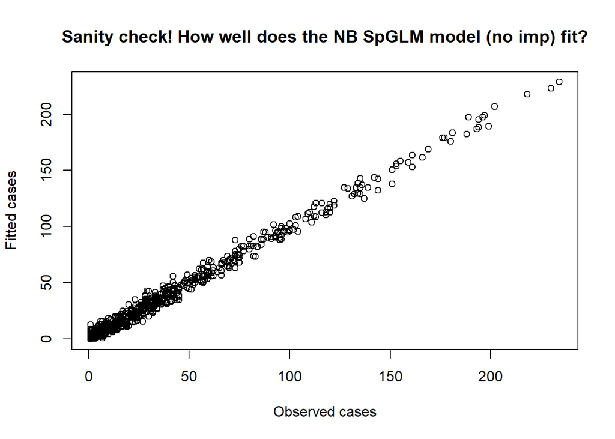

```r
NOIMPoutput.nb.fitted <- NOIMPoutput.nb$summary.fitted.values$mean
NOIMPoutput.nb.fitted <- abs(NOIMPoutput.nb.fitted)
plot(ncases[-which(is.na(ncases))], NOIMPoutput.nb.fitted[-which(is.na(ncases))],
     main = "Sanity check! How well does the NB SpGLM model (no imp) fit?",
     xlab = "Observed cases", ylab = "Fitted cases")
```

```r
#RSE Sp Neg Bin WITHOUT any imputation
RelativeSquaredError(realized = ncases, predicted = NOIMPoutput.nb.fitted)
```

```
## [1] 0.008508548
```

```r
#RMSE Sp Neg Bin WITHOUT any imputation
RMSE.nb.noimp <-
  sqrt(mean((ncases[-which(is.na(ncases))] - NOIMPoutput.nb.fitted[-which(is.na(ncases))])^2))
RMSE.nb.noimp
```

```
## [1] 3.852171
```

# Non-spatial

```r
formula.noimp.nsp = ncases ~ 1 + sdi_score + pm2.5 + prcnt_black + prcnt_white + prcnt_hisp + prcnt_male + prcnt_65over + binge_dr +
  smoking_idx + obesity_idx + pct_poverty + offset(log(totalpop))


# Poisson family
NOIMPoutput.p.nsp = inla(formula.noimp.nsp, data = as.data.frame(df.INLA),
                         family = "poisson", verbose = FALSE,
                         control.predictor = list(compute = TRUE),
                         control.compute = list(dic = TRUE, waic = TRUE,
                                                mlik = TRUE))
NOIMPoutput.p.nsp <- inla.rerun(NOIMPoutput.p.nsp)
summary(NOIMPoutput.p.nsp)
```

```
##
## Call:
##    c("inla.core(formula = formula, family = family, contrasts = contrasts,
##    ", " data = data, quantiles = quantiles, E = E, offset = offset, ", "
##    scale = scale, weights = weights, Ntrials = Ntrials, strata = strata,
##    ", " lp.scale = lp.scale, link.covariates = link.covariates, verbose =
##    verbose, ", " lincomb = lincomb, selection = selection, control.compute
##    = control.compute, ", " control.predictor = control.predictor,
##    control.family = control.family, ", " control.inla = control.inla,
##    control.fixed = control.fixed, ", " control.mode = control.mode,
##    control.expert = control.expert, ", " control.hazard = control.hazard,
##    control.lincomb = control.lincomb, ", " control.update =
##    control.update, control.lp.scale = control.lp.scale, ", "
##    control.pardiso = control.pardiso, only.hyperparam = only.hyperparam,
##    ", " inla.call = inla.call, inla.arg = inla.arg, num.threads =
##    num.threads, ", " blas.num.threads = blas.num.threads, keep = keep,
##    working.directory = working.directory, ", " silent = silent, inla.mode
##    = inla.mode, safe = FALSE, debug = debug, ", " .parent.frame =
##    .parent.frame)")
## Time used:
##     Pre = 0.555, Running = 0.233, Post = 0.0667, Total = 0.855
## Fixed effects:
##                mean    sd 0.025quant 0.5quant 0.975quant mode kld
## (Intercept)  -5.225 0.008     -5.240   -5.225     -5.209   NA   0
## sdi_score     0.067 0.014      0.040    0.067      0.095   NA   0
## pm2.5        -0.066 0.007     -0.081   -0.066     -0.052   NA   0
## prcnt_black   0.248 0.033      0.184    0.248      0.312   NA   0
## prcnt_white   0.274 0.032      0.213    0.274      0.336   NA   0
## prcnt_hisp   -0.048 0.009     -0.066   -0.048     -0.030   NA   0
## prcnt_male   -0.080 0.017     -0.112   -0.080     -0.047   NA   0
## prcnt_65over  0.274 0.020      0.234    0.274      0.313   NA   0
## binge_dr     -0.039 0.013     -0.065   -0.039     -0.013   NA   0
## smoking_idx   0.155 0.017      0.122    0.155      0.189   NA   0
## obesity_idx   0.048 0.017      0.015    0.048      0.082   NA   0
## pct_poverty  -0.144 0.018     -0.179   -0.144     -0.109   NA   0
##
## Deviance Information Criterion (DIC) ...............: 5446.34
## Deviance Information Criterion (DIC, saturated) ....: -3250.53
## Effective number of parameters .....................: 12.13
##
## Watanabe-Akaike information criterion (WAIC) ...: 5464.33
## Effective number of parameters .................: 28.99
##
## Marginal log-Likelihood:  -2802.51
##  is computed
## Posterior summaries for the linear predictor and the fitted values are computed
## (Posterior marginals needs also 'control.compute=list(return.marginals.predictor=TRUE)')
```

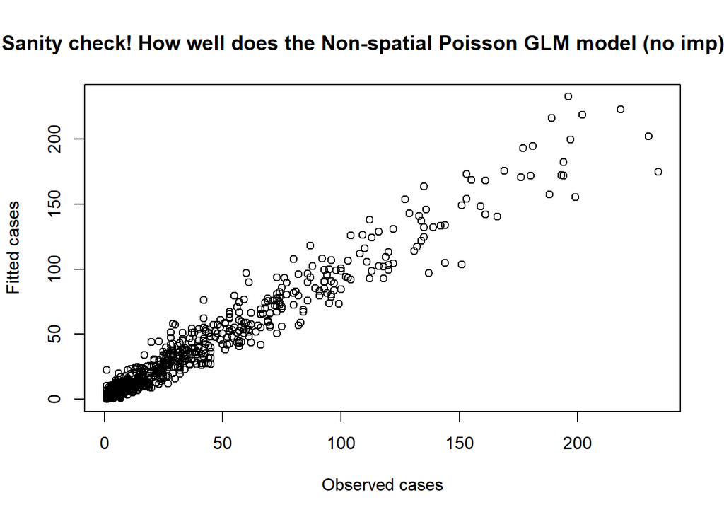

```r
NOIMPoutput.p.nsp.fitted <- NOIMPoutput.p.nsp$summary.fitted.values$mean
NOIMPoutput.p.nsp.fitted <- abs(NOIMPoutput.p.nsp.fitted)
plot(ncases[-which(is.na(ncases))], NOIMPoutput.p.nsp.fitted[-which(is.na(ncases))],
     main = "Sanity check! How well does the Non-spatial Poisson GLM model (no imp) fit?",
     xlab = "Observed cases", ylab = "Fitted cases")
```

```r
#RSE non Sp Poisson WITHOUT any imputation
RelativeSquaredError(realized = ncases, predicted = NOIMPoutput.p.nsp.fitted)
```

```
## [1] 0.04582402
```

```r
#RMSE non Sp Poisson WITHOUT any imputation
RMSE.p.noimp.nsp <-
  sqrt(mean((ncases[-which(is.na(ncases))] - NOIMPoutput.p.nsp.fitted[-which(is.na(ncases))])^2))
RMSE.p.noimp.nsp
```

```
## [1] 8.93973
```